# Tutorial: Using ProMetIS data

Alyssa Imbert and Etienne A. Thévenot (ProMetIS consortium)

16 juin 2023

[figure not shown]

This vignette describes how to upload the data from the package.

Note: The `MutiDataSet`/`ExpressionSet` Bioconductor framework is used throughout this vignette (Hernandez-Ferrer et al. 2017).

# 1 Data upload

The path to the post-processed data stored in the package can be accessed as follows:

```r
data_dir.c <- ProMetIS::post_processed_dir.c()
```

In this tutorial, we will focus on the metabolomics datasets:

```r
met_sets.vc <- grep("metabolomics_",
                    ProMetIS::sets.vc(),
                    value = TRUE)
```

Each dataset is stored as 3 tabulated files containing the matrix of intensities, and the sample and variable metadata, respectively. The tables can be uploaded as a `MutiDataSet` object with the [phenomis](https://bioconductor.org/packages/phenomis/) package from Bioconductor:

```r
met.mds <- phenomis::reading(data_dir.c,
                             subsets.vc = met_sets.vc,
                             output.c = "set",
                             report.c = "none")
```

We further restrict to the liver data from the MX2 mice:

```r
mx2_liv_met.mds <- ProMetIS::subsetting(met.mds,
                                         genes.vc = c("WT", "MX2"),
                                         tissues.vc = "liver")
```

# 2 Data analysis

We provide below two examples of single and multi-omics analysis.

The comprehensive analysis and biologicial interpretation of the datasets are currently beeing finalized by the consortium and will be soon made publicly available. Feel free to contact us for any question (etienne.thevenot@cea.fr).

## 2.1 Single-omics

Let us first focus on the data obtained with the HILIC chromatographic column in the negative mode:

```r
mx2_liv_met_hilic.eset <- mx2_liv_met.mds[["metabolomics_liver_hilic_neg"]]
```

The genotype information can be extracted from the sample metadata:

```r
gene.fc <- factor(Biobase::pData(mx2_liv_met_hilic.eset)[, "gene"],
                  levels = c("WT", "MX2"))
```

Let us compute an Orthogonal Partial Least Square - Discriminant Analysis (OPLS-DA) model of the genotype response:

```r
ropls::opls(t(Biobase::exprs(mx2_liv_met_hilic.eset)), gene.fc,
            predI = 1, orthoI = 1)
```

```
## OPLS-DA
## 29 samples x 2866 variables and 1 response
## standard scaling of predictors and response(s)
##       R2X(cum) R2Y(cum) Q2(cum) RMSEE pre ort pR2Y  pQ2
## Total    0.166    0.918   0.542 0.151   1   1 0.05 0.05
```

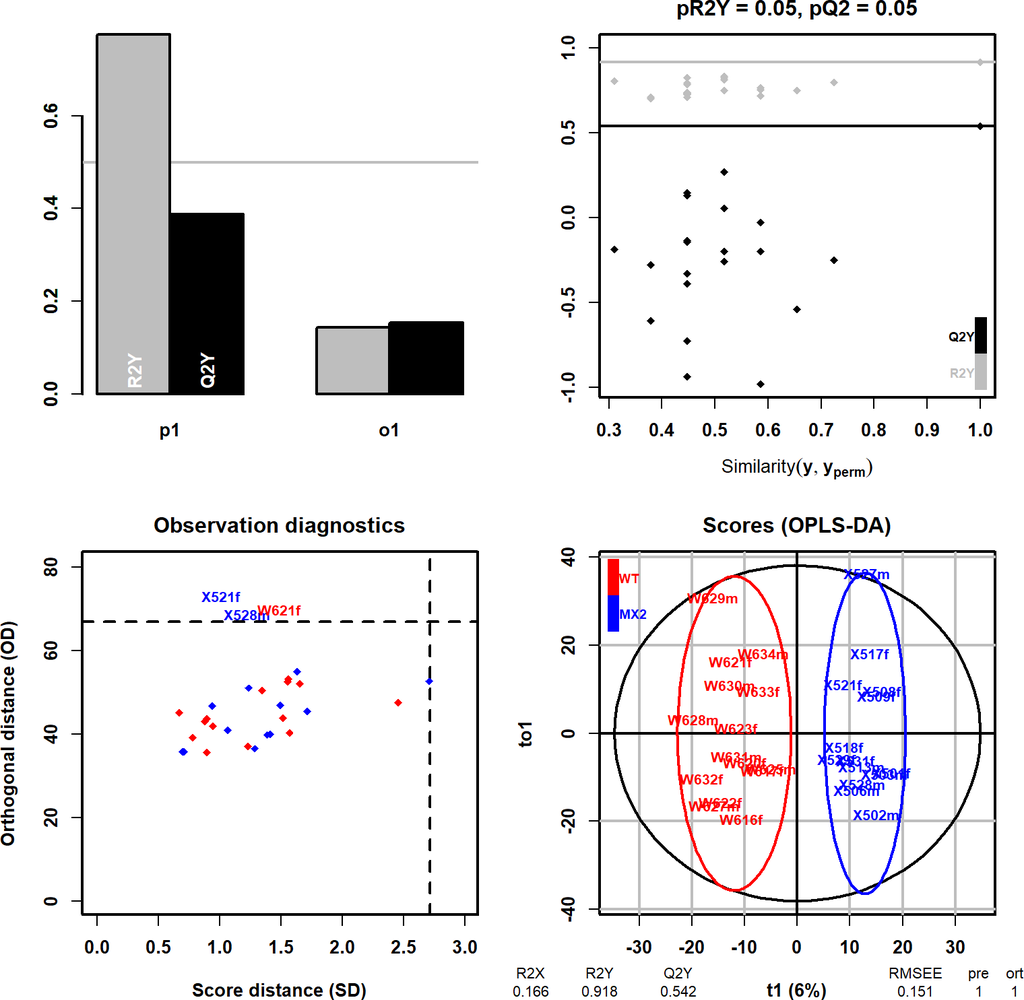

## 2.2 Multi-omics analysis

Let us now provide an example of exploration of the relationships between the datasets by using Multiple Co-Inertia (Chessel and Hanafi 1996).

We first extract the list of matrices:

```r
mx2_liv_met_mn.ls <- MultiDataSet::as.list(mx2_liv_met.mds)
```

We then perform the analysis by using the implementation in the [omicade4](https://bioconductor.org/packages/omicade4/) package (Meng et al. 2014):

```r
mx2_liv_met.mcia <- omicade4::mcia(mx2_liv_met_mn.ls, cia.nf = 3)
```

For each sample, the 2 blocks as well as the reference structure maximizing the covariance can be plotted (here in the 2nd and 3rd dimensions) with:

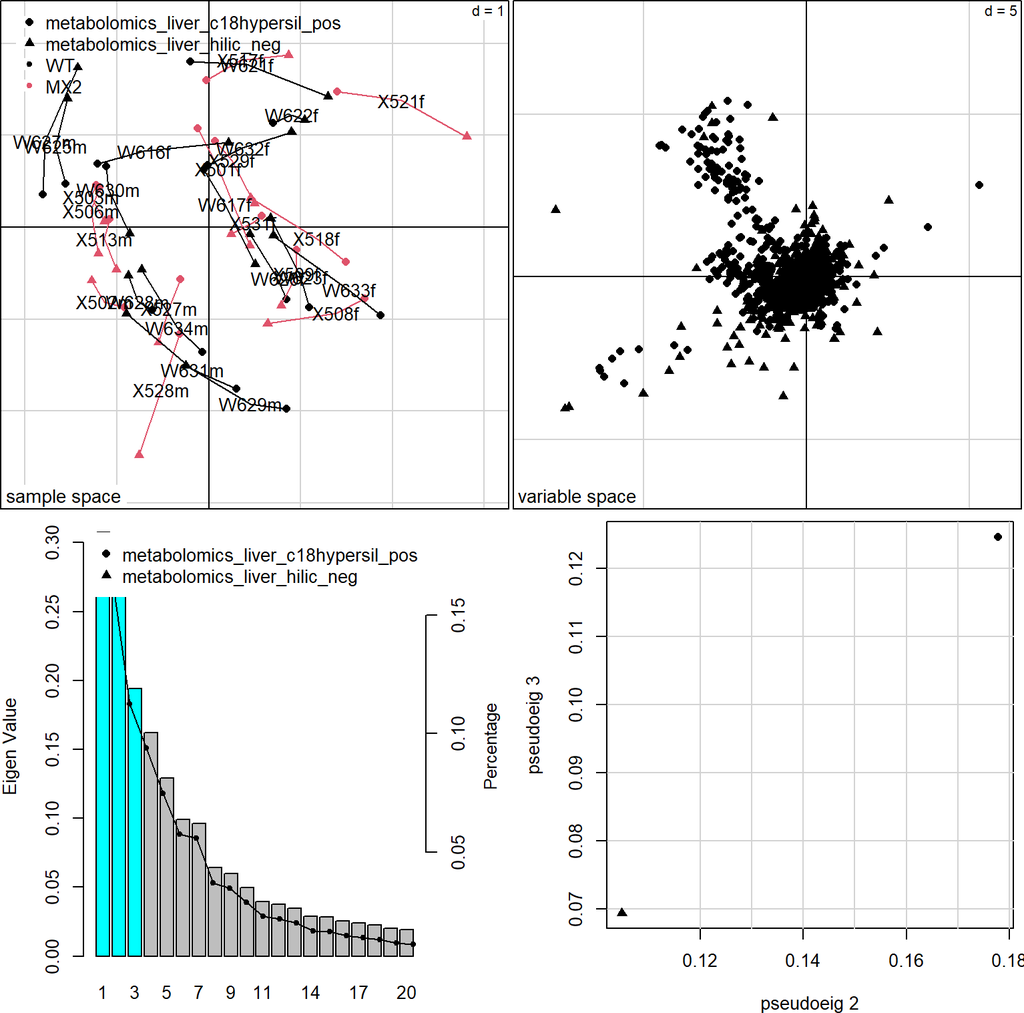

```r
require(ade4)
omicade4::plot.mcia(mx2_liv_met.mcia, axes = 2:3,
                    phenovec = gene.fc)
```

# References

Chessel, D., and M. Hanafi. 1996. “Analyses de La Co-Inertie de K Nuages de Points.” *Revue de Statistique Appliquée* 44 (2): 35–60.

Hernandez-Ferrer, Carles, Carlos Ruiz-Arenas, Alba Beltran-Gomila, and Juan R. González. 2017. “MultiDataSet: An R Package for Encapsulating Multiple Data Sets with Application to Omic Data Integration.” *BMC Bioinformatics* 18 (1): 36. https://doi.org/10.1186/s12859-016-1455-1.

Meng, Chen, Bernhard Kuster, Aedin C. Culhane, and Amin Moghaddas Gholami. 2014. “A Multivariate Approach to the Integration of Multi-Omics Datasets.” *BMC Bioinformatics* 15 (1): 1–13. https://doi.org/10.1186/1471-2105-15-162.